# EDA SIP

## O que são os dados

```
## Observations: 12,299
## Variables: 17
## $ TaskNumber           <chr> "1735", "1742", "1971", "2134", "2251", "22…
## $ Summary              <chr> "Flag RI on SCM Message Summary screen usin…
## $ Priority             <dbl> 1, 1, 2, 5, 10, 1, 5, 5, 6, 5, 2, 1, 3, 1, …
## $ RaisedByID           <chr> "58", "58", "7", "50", "46", "13", "13", "1…
## $ AssignedToID         <chr> "58", "42", "58", "42", "13", "13", "13", "…
## $ AuthorisedByID       <chr> "6", "6", "6", "6", "6", "58", "6", "6", "6…
## $ StatusCode           <chr> "FINISHED", "FINISHED", "FINISHED", "FINISH…
## $ ProjectCode          <chr> "PC2", "PC2", "PC2", "PC2", "PC2", "PC9", "…
## $ ProjectBreakdownCode <chr> "PBC42", "PBC21", "PBC75", "PBC42", "PBC21"…
## $ Category             <chr> "Development", "Development", "Operational"…
## $ SubCategory          <chr> "Enhancement", "Enhancement", "In House Sup…
## $ HoursEstimate        <dbl> 14.00, 7.00, 0.70, 0.70, 3.50, 7.00, 7.00, …
## $ HoursActual          <dbl> 1.75, 7.00, 0.70, 0.70, 3.50, 7.00, 7.00, 7…
## $ DeveloperID          <chr> "58", "42", "58", "42", "13", "13", "43", "…
## $ DeveloperHoursActual <dbl> 1.75, 7.00, 0.70, 0.70, 3.50, 7.00, 7.00, 7…
## $ TaskPerformance      <dbl> 12.25, 0.00, 0.00, 0.00, 0.00, 0.00, 0.00, …
## $ DeveloperPerformance <dbl> 12.25, 0.00, 0.00, 0.00, 0.00, 0.00, NA, 0.…
```

## Entendendo os dados

```
## Skim summary statistics
##  n obs: 12299
##  n variables: 4
##
## ── Variable type:character ─────────────────────────────────────────────────────────────────────────────────────────────────
##     variable missing complete     n min max empty n_unique
##  ProjectCode       0    12299 12299   3   4     0       20
##   TaskNumber       0    12299 12299   4   5     0    10266
##
## ── Variable type:numeric ───────────────────────────────────────────────────────────────────────────────────────────────────
##       variable missing complete     n  mean    sd   p0 p25 p50 p75    p100
##    HoursActual       0    12299 12299 13.18 68.72 0.01   1   3 8.5 2490.16
##  HoursEstimate       0    12299 12299 10.15 28.84 0.01   1   3 7    910
##      hist
##  ▇▁▁▁▁▁▁▁
##  ▇▁▁▁▁▁▁▁
```

Temos 20 projetos, com 12299 estimativas_raw. Não há apenas uma estimativa por tarefa, já que há apenas 10266 valores distintos de `TaskNumber`.

```
## # A tibble: 1,384 x 2
## # Groups:   TaskNumber [1,384]
##    TaskNumber     n
##    <chr>      <int>
##  1 10605          8
##  2 6889           8
##  3 10089          7
##  4 10974          7
##  5 11056          7
##  6 11270          7
##  7 13124          7
##  8 13190          7
##  9 13253          7
## 10 3812           7
## # … with 1,374 more rows
```

### 1 estimativa por task

Para nossa análise, usaremos uma estimativa por task. Caso haja mais de uma usaremos a média das estimativas_raw:

### Dados por time

```
## Observations: 20
## Variables: 4
## $ ProjectCode    <chr> "PC1", "PC10", "PC11", "PC12", "PC13", "PC14", "P…
## $ devs           <int> 4, 4, 11, 3, 6, 11, 3, 8, 10, 15, 1, 16, 2, 5, 8,…
## $ erro_medio_abs <dbl> 18.514444, 35.907123, 4.604863, 8.271852, 8.50035…
## $ estimativas    <int> 54, 73, 292, 54, 171, 105, 3, 114, 449, 2888, 41,…
```

## Qual a relação entre as estimativas e horas reais tomadas na empresa como um todo e em diferentes categorias de tarefa?

```
## Observations: 10,268
## Variables: 8
## $ ProjectCode          <chr> "PC1", "PC1", "PC1", "PC1", "PC1", "PC1", "…
## $ TaskNumber           <chr> "11276", "11286", "11294", "11306", "11313"…
## $ Category             <chr> "Management", "Development", "Development",…
## $ Priority             <dbl> 3, 1, 1, 1, 1, 1, 1, 1, 1, 1, 1, 1, 1, 1, 1…
## $ Summary              <chr> "Meeting with CCC - CCC Contract and Quotat…
## $ HoursEstimate        <dbl> 14.0, 35.0, 21.0, 14.0, 28.0, 14.0, 49.0, 1…
## $ HoursActual          <dbl> 10.00, 22.25, 44.00, 9.00, 7.00, 27.50, 2.0…
## $ DeveloperPerformance <dbl> NA, 12.75, NA, 5.00, 21.00, -13.50, 47.00, …
```

Ao avaliar a relação entre duas variáveis, é importante determinar como as variáveis estão relacionadas. Relações lineares são mais comuns, mas as variáveis também podem ter uma relação não linear ou monotônica, como mostrado abaixo. Também é possível que não haja nenhuma relação entre as variáveis. Na tentativa de clarificar nossos estudos sobre as relações criamos um gráfico de dispersão das variáveis para avaliar a relação. Visualmente é possível perceber não fica muito claro estabelecer uma relação de linearidade entre as duas variáves.

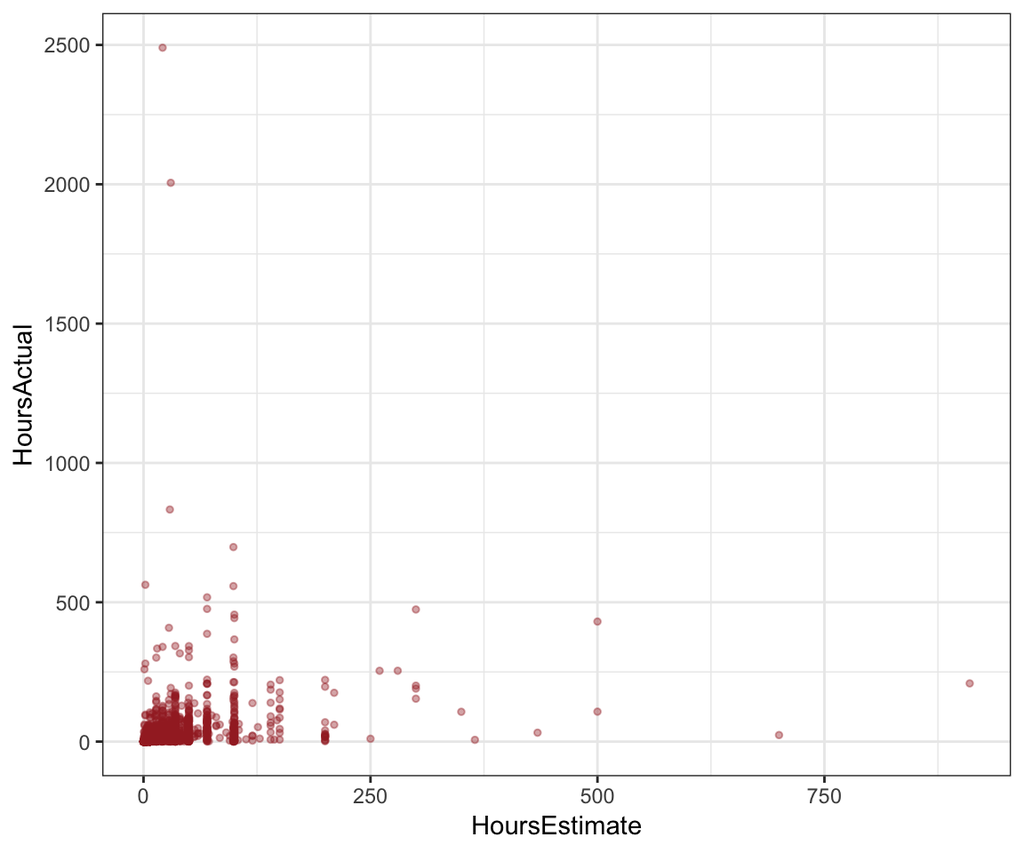

Como forma de aprofundar nossas percepções apresentamos uma comparação das possíveis correlações possíveis. Em uma relação monotônica, as variáveis tendem a mover-se na mesma direção relativa, mas não necessariamente a uma taxa constante. Em uma relação linear, as variáveis se movem na mesma direção, a uma taxa constante. O coeficiente de correlação de Pearson para esses dados é 0.316, mas a correlação de Spearman é maior, 0.826.

```
## # A tibble: 1 x 3
##   pearson_corr spearman_corr kendall_corr
##          <dbl>         <dbl>        <dbl>
## 1        0.316         0.826        0.696
```

```
## # A tibble: 3 x 4
##   Category    pearson_corr spearman_corr kendall_corr
##   <chr>              <dbl>         <dbl>        <dbl>
## 1 Development        0.377         0.835        0.700
## 2 Management         0.456         0.753        0.635
## 3 Operational        0.159         0.842        0.729
```

## Equipes com mais desenvolvedores produzem estimativas com mais ou menos erro que equipes menores?

```
## Observations: 20
## Variables: 4
## $ ProjectCode    <chr> "PC1", "PC10", "PC11", "PC12", "PC13", "PC14", "P…
## $ devs           <int> 4, 4, 11, 3, 6, 11, 3, 8, 10, 15, 1, 16, 2, 5, 8,…
## $ erro_medio_abs <dbl> 18.514444, 35.907123, 4.604863, 8.271852, 8.50035…
## $ estimativas    <int> 54, 73, 292, 54, 171, 105, 3, 114, 449, 2888, 41,…
```

Primeiro passo, examinar o formato dos dados.

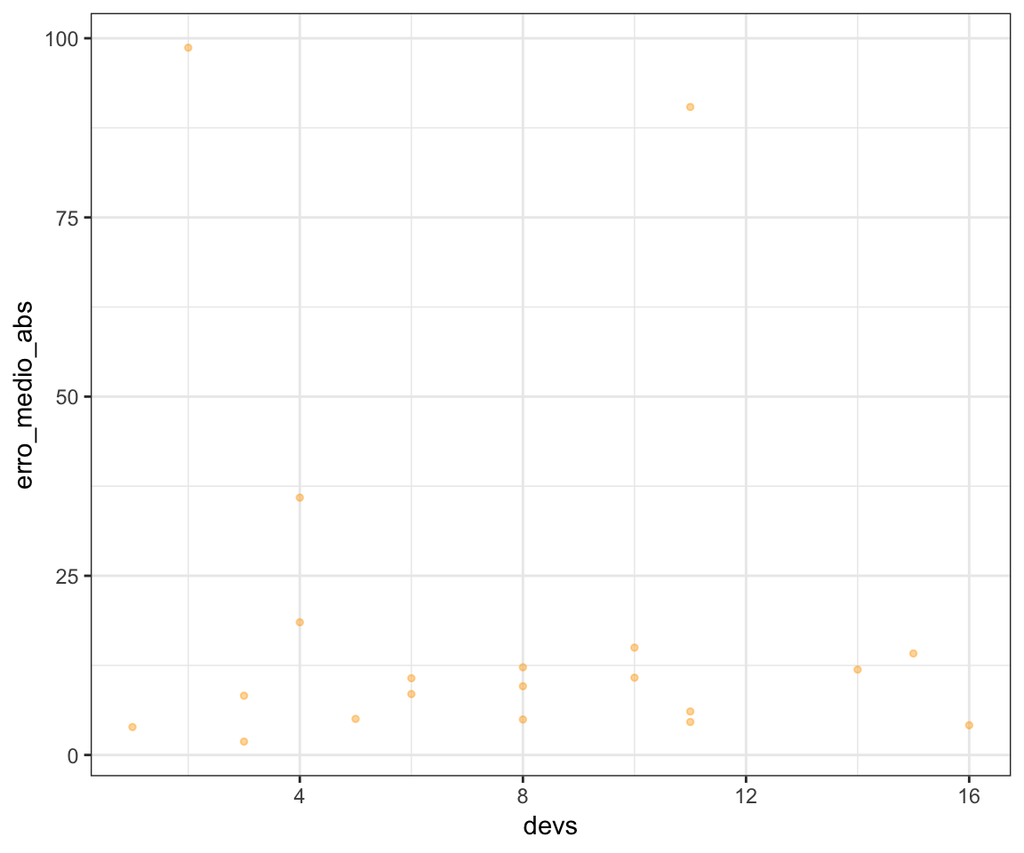

É possível observar que temos alguns projetos que fogem ao padrão do erro médio absoluto.

```
## # A tibble: 3 x 4
##   ProjectCode  devs erro_medio_abs estimativas
##   <chr>       <int>          <dbl>       <int>
## 1 PC10            4           35.9          73
## 2 PC14           11           90.4         105
## 3 PC20            2           98.7           5
```

```
## # A tibble: 1 x 3
##   pearson_corr spearman_corr kendall_corr
##          <dbl>         <dbl>        <dbl>
## 1       -0.137        0.0438       0.0324
```